# EasyVisa Project

## Context:

Business communities in the United States are facing high demand for human resources, but one of the constant challenges is identifying and attracting the right talent, which is perhaps the most important element in remaining competitive. Companies in the United States look for hard-working, talented, and qualified individuals both locally as well as abroad.

The Immigration and Nationality Act (INA) of the US permits foreign workers to come to the United States to work on either a temporary or permanent basis. The act also protects US workers against adverse impacts on their wages or working conditions by ensuring US employers' compliance with statutory requirements when they hire foreign workers to fill workforce shortages. The immigration programs are administered by the Office of Foreign Labor Certification (OFLC).

OFLC processes job certification applications for employers seeking to bring foreign workers into the United States and grants certifications in those cases where employers can demonstrate that there are not sufficient US workers available to perform the work at wages that meet or exceed the wage paid for the occupation in the area of intended employment.

## Objective:

In FY 2016, the OFLC processed 775,979 employer applications for 1,699,957 positions for temporary and permanent labor certifications. This was a nine percent increase in the overall number of processed applications from the previous year. The process of reviewing every case is becoming a tedious task as the number of applicants is increasing every year.

The increasing number of applicants every year calls for a Machine Learning based solution that can help in shortlisting the candidates having higher chances of VISA approval. OFLC has hired your firm EasyVisa for data-driven solutions. You as a data scientist have to analyze the data provided and, with the help of a classification model:

- Facilitate the process of visa approvals.
- Recommend a suitable profile for the applicants for whom the visa should be certified or denied based on the drivers that significantly influence the case status.

## Data Description

The data contains the different attributes of the employee and the employer. The detailed data dictionary is given below.

- case_id: ID of each visa application
- continent: Information of continent the employee
- education_of_employee: Information of education of the employee
- has_job_experience: Does the employee has any job experience? Y= Yes; N = No
- requires_job_training: Does the employee require any job training? Y = Yes; N = No
- no_of_employees: Number of employees in the employer's company
- yr_of_estab: Year in which the employer's company was established
- region_of_employment: Information of foreign worker's intended region of employment in the US.
- prevailing_wage: Average wage paid to similarly employed workers in a specific occupation in the area of intended employment. The purpose of the prevailing wage is to ensure that the foreign worker is not underpaid compared to other workers offering the same or similar service in the same area of employment.
- unit_of_wage: Unit of prevailing wage. Values include Hourly, Weekly, Monthly, and Yearly.
- full_time_position: Is the position of work full-time? Y = Full Time Position; N = Part Time Position
- case_status: Flag indicating if the Visa was certified or denied

## Importing necessary libraries and data

```python
# Installing the libraries with the specified version.
!pip install xgboost==2.0.3
```

**Note**: *After running the above cell, kindly restart the notebook kernel and run all cells sequentially from the start again.*

```python
import numpy as np
import pandas as pd
import seaborn as sns
import matplotlib.pyplot as plt
%matplotlib inline

# importing the sklearn and model_selection
from sklearn import metrics
from sklearn.ensemble import AdaBoostClassifier,BaggingClassifier,GradientBoostingClassifier,RandomForestClassifier
import statsmodels.api as sm
from sklearn.tree import DecisionTreeClassifier
from sklearn import tree
from sklearn.tree import export_graphviz
from sklearn.model_selection import train_test_split,GridSearchCV
from sklearn.metrics import confusion_matrix
from xgboost import XGBClassifier
from sklearn.ensemble import StackingClassifier
```

## Data Overview

- Observations
- Sanity checks

### Read the data

```python
data= pd.read_csv("EasyVisa.csv")
df= data.copy()
df.head()
```

|  | case_id | continent | education_of_employee | has_job_experience | requires_job_training | no_of_employees | yr_of_estab | region_of_employment | prevailing_wage | unit_of_wage | full_time_position | case_status |
| --- | --- | --- | --- | --- | --- | --- | --- | --- | --- | --- | --- | --- |
| 0 | EZYV01 | Asia | High School | N | N | 14513 | 2007 | West | 592.2029 | Hour | Y | Denied |
| 1 | EZYV02 | Asia | Master's | Y | N | 2412 | 2002 | Northeast | 83425.6500 | Year | Y | Certified |
| 2 | EZYV03 | Asia | Bachelor's | N | Y | 44444 | 2008 | West | 122996.8600 | Year | Y | Denied |
| 3 | EZYV04 | Asia | Bachelor's | N | N | 98 | 1897 | West | 83434.0300 | Year | Y | Denied |
| 4 | EZYV05 | Africa | Master's | Y | N | 1082 | 2005 | South | 149907.3900 | Year | Y | Certified |

### checking the Shape, Describtion, and info of the data

```python
df.shape
```

```
(25480, 12)
```

*Observation*

- The data has 25480 rows and 12 columns

```python
df.describe()
```

|  | no_of_employees | yr_of_estab | prevailing_wage |
| --- | --- | --- | --- |
| count | 25480.000000 | 25480.000000 | 25480.000000 |
| mean | 5667.043210 | 1979.409929 | 74455.814592 |
| std | 22877.928848 | 42.366929 | 52815.942327 |
| min | -26.000000 | 1800.000000 | 2.136700 |
| 25% | 1022.000000 | 1976.000000 | 34015.480000 |
| 50% | 2109.000000 | 1997.000000 | 70308.210000 |
| 75% | 3504.000000 | 2005.000000 | 107735.512500 |
| max | 602069.000000 | 2016.000000 | 319210.270000 |

*Observation*

- The Oldest company that is yr_of_estab is 216 year back
- Prevailing_wage min is 2.14 Dollar. Which need to check in further.
- no_of_employees which is in negitive -26 need to check in further.

```python
df.info()
```

```
<class 'pandas.core.frame.DataFrame'>
RangeIndex: 25480 entries, 0 to 25479
Data columns (total 12 columns):
 #   Column                 Non-Null Count  Dtype
---  ------                 --------------  -----
 0   case_id                25480 non-null  object
 1   continent              25480 non-null  object
 2   education_of_employee  25480 non-null  object
 3   has_job_experience     25480 non-null  object
 4   requires_job_training  25480 non-null  object
 5   no_of_employees        25480 non-null  int64
 6   yr_of_estab            25480 non-null  int64
 7   region_of_employment   25480 non-null  object
 8   prevailing_wage        25480 non-null  float64
 9   unit_of_wage           25480 non-null  object
 10  full_time_position     25480 non-null  object
 11  case_status            25480 non-null  object
dtypes: float64(1), int64(2), object(9)
memory usage: 2.3+ MB
```

*Observation*

- The Data-set has 1-float, 2-int and 9-object
- There is no null values in the data-set
- Need to check for the duplicates in the data-set

### Checking the null and duplicates in Data-Set

```python
df.isnull().sum()
```

```
case_id                  0
continent                0
education_of_employee    0
has_job_experience       0
requires_job_training    0
no_of_employees          0
yr_of_estab              0
region_of_employment     0
prevailing_wage          0
unit_of_wage             0
full_time_position       0
case_status              0
dtype: int64
```

*Observation*

- There is no null in the dataset

```python
df.duplicated().sum()
```

```
0
```

*Observation*

- There is no dulicates in the dataset

### Checking for categorical data

```python
cat=df.select_dtypes(include=np.object_).columns.to_list()
for i in  (cat):
    print(df[i].value_counts())
    print("***"*25)
```

```
case_id
EZYV01       1
EZYV16995    1
EZYV16993    1
EZYV16992    1
EZYV16991    1
            ..
EZYV8492     1
EZYV8491     1
EZYV8490     1
EZYV8489     1
EZYV25480    1
Name: count, Length: 25480, dtype: int64
continent
Asia             16861
Europe            3732
North America     3292
South America      852
Africa             551
Oceania            192
Name: count, dtype: int64
education_of_employee
Bachelor's     10234
Master's        9634
High School     3420
Doctorate       2192
Name: count, dtype: int64
has_job_experience
Y    14802
N    10678
Name: count, dtype: int64
requires_job_training
N    22525
Y     2955
Name: count, dtype: int64
region_of_employment
Northeast    7195
South        7017
West         6586
Midwest      4307
Island        375
Name: count, dtype: int64
unit_of_wage
Year     22962
Hour      2157
Week       272
Month       89
Name: count, dtype: int64
full_time_position
Y    22773
N     2707
Name: count, dtype: int64
case_status
Certified    17018
Denied        8462
Name: count, dtype: int64
```

*Observation*

- `education_of_employee`: Max number of have Bachelor's (10234), and followed by Master's(9634)
- `has_job_experience`: Max Number of people have the job experience (14802).
- `requires_job_training`: Very Less amount of people required job Training.
- `continent`: Asia(16861) are the heighest
- `full_time_position`:22773 are fulltime employees

## Exploratory Data Analysis (EDA)

- EDA is an important part of any project involving data.
- It is important to investigate and understand the data better before building a model with it.
- A few questions have been mentioned below which will help you approach the analysis in the right manner and generate insights from the data.
- A thorough analysis of the data, in addition to the questions mentioned below, should be done.

### Creating the functions for the EDA

```python
def boxplot_histogram(data, feature , figsize=(15,10), kde=False):
    f,(ax_1,ax_2)=plt.subplots(nrows=2,sharex=True,gridspec_kw={"height_ratios": (0.25, 0.75)},figsize=figsize)
    sns.boxplot(data,x=feature,ax=ax_1,showmeans=True,color="red")
    sns.histplot(data,x=feature,ax=ax_2,kde=kde)
    ax_2.axvline(data[feature].mean(),color="red",ls="--")
    ax_2.axvline(data[feature].median(),color="black",ls="-")
```

```python
def labeled_barplot(data, feature, perc= True, n=None):
    """
    data :the name of the dataset
    feature:the name of the feature
    count:number of values in the count
    total= what number number need to show
    """
    count= data[feature].nunique()
    total= len(data[feature])
    # if the user give the n value we will pass the n else take the nunique values
    if n is None:
        plt.figure(figsize=(count+2,6))
    else:
        plt.figure(figsize=(n+2,6))
    plt.xticks(rotation=90,fontsize=15)
    ax=sns.countplot(data,x=feature,palette="Paired",order=data[feature].value_counts().index[:n])
    for p in ax.patches:
        if perc == True:
            label = "{:.1f}%".format(
                100 * p.get_height() / total
            )  # percentage of each class of the category
        else:
            label = p.get_height()  # count of each level of the category

        x = p.get_x() + p.get_width() / 2  # width of the plot
        y = p.get_height()  # height of the plot

        ax.annotate(
            label,
            (x, y),
            ha="center",
            va="center",
            size=12,
            xytext=(0, 5),
            textcoords="offset points",
        )  # annotate the percentage

    plt.show()  # show the plot
```

### Univariate analysis for Numerical

*prevailing_wage*

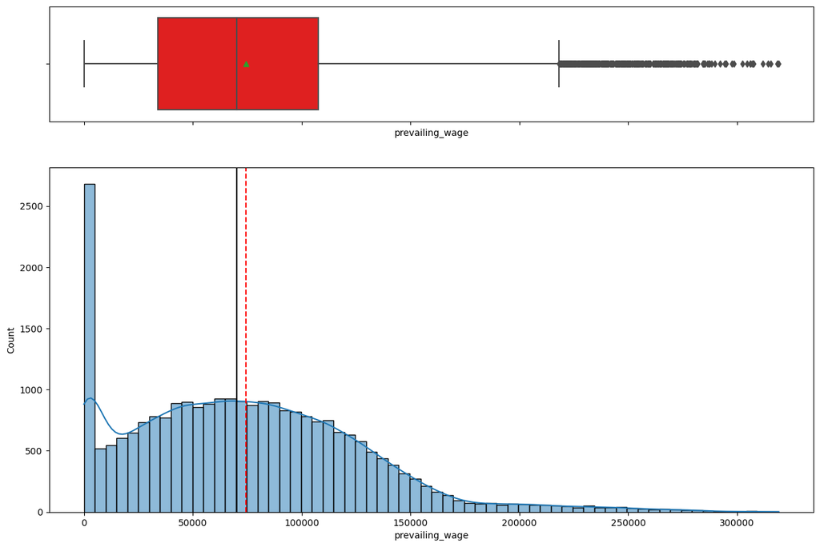

```python
boxplot_histogram(df,"prevailing_wage",kde=True)
```

*Observation*

- `prevailing_wage` are classified as hourly monthly and yearly
- `prevailing_wage` need to do feature engineering

*yr_of_estab*

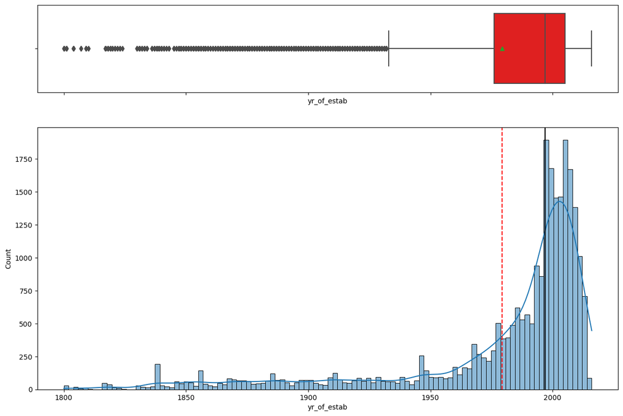

```python
boxplot_histogram(df,"yr_of_estab",kde=True)
```

*Observation*

- `yr_of_estab` is skewed towards left, The oldest company established was 1800
- `yr_of_estab` has huge volume is increased from 1990 to 2016, So there are huge volume of outliers at min end whiskers

*no_of_employees*

- we found ou there are negitive number of employees so we use abs which convert them into positive numbers

```python
df["no_of_employees"]=np.abs(df["no_of_employees"])
```

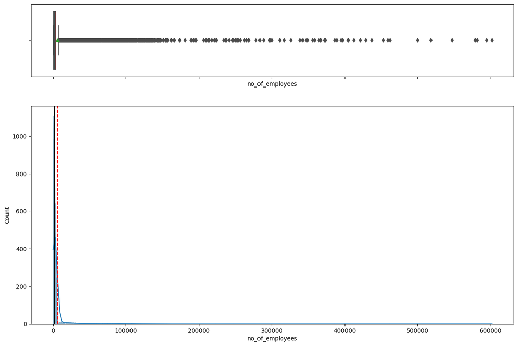

```python
boxplot_histogram(df,"no_of_employees",kde=True)
```

*Observation*

### Categorical Univariate analysis

```python
df.info()
```

```
<class 'pandas.core.frame.DataFrame'>
RangeIndex: 25480 entries, 0 to 25479
Data columns (total 12 columns):
 #   Column                 Non-Null Count  Dtype
---  ------                 --------------  -----
 0   case_id                25480 non-null  object
 1   continent              25480 non-null  object
 2   education_of_employee  25480 non-null  object
 3   has_job_experience     25480 non-null  object
 4   requires_job_training  25480 non-null  object
 5   no_of_employees        25480 non-null  int64
 6   yr_of_estab            25480 non-null  int64
 7   region_of_employment   25480 non-null  object
 8   prevailing_wage        25480 non-null  float64
 9   unit_of_wage           25480 non-null  object
 10  full_time_position     25480 non-null  object
 11  case_status            25480 non-null  object
dtypes: float64(1), int64(2), object(9)
memory usage: 2.3+ MB
```

*Observation*

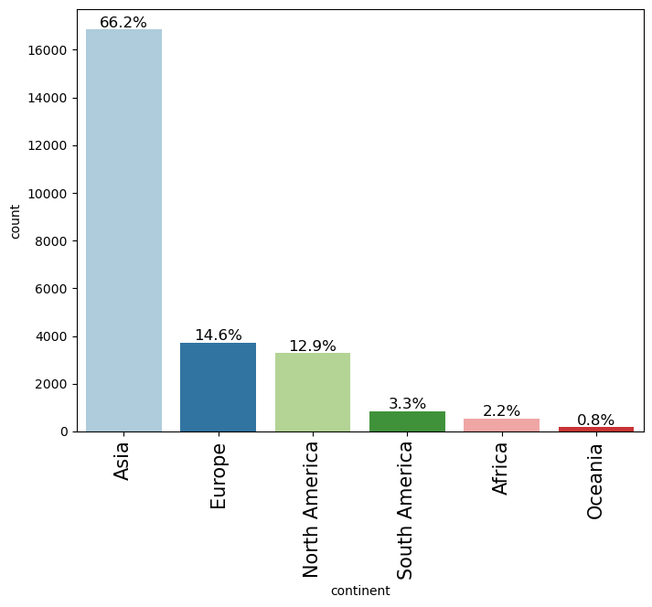

```python
labeled_barplot(df,"continent",perc=True)
```

*Observation*

- The majority of the pople who applied for the visa are Asia with 66.2%

*education_of_employee*

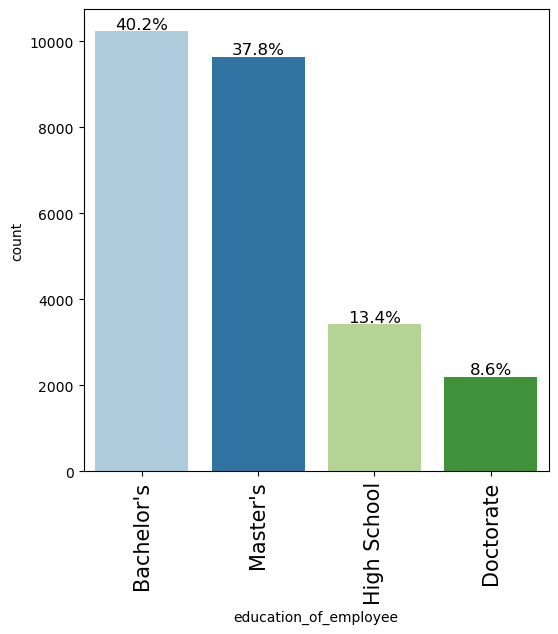

```python
labeled_barplot(df,"education_of_employee",perc=True)
```

*Observation*

- people who completed there bachelor's and masters are highest
- The People who completed there Doctor Degree are the least

*has_job_experience*

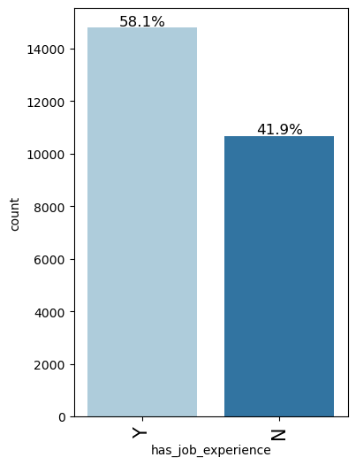

```python
labeled_barplot(df,"has_job_experience",perc=True)
```

*Observation*

- more half percentage has_job_experience
- This give more info with multiple combinations

*requires_job_training*

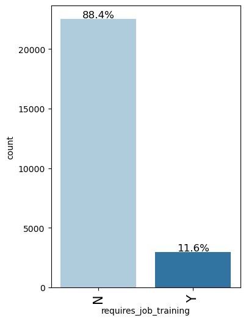

```python
labeled_barplot(df,"requires_job_training",perc=True)
```

*Observation*

- Very few percentage requires_job_training (11.6%)
- which mean most skilled people had applied

*region_of_employment*

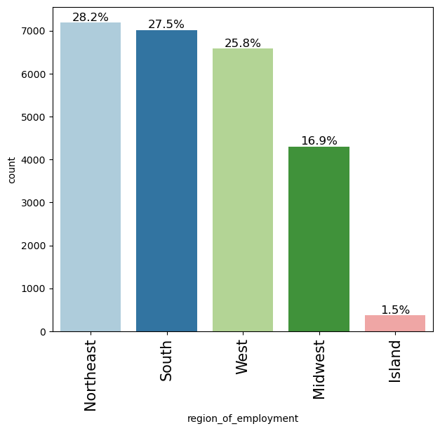

```python
labeled_barplot(df,"region_of_employment",perc=True)
```

*Observation*

- foreign worker's intended region of employment are Northeast and south and followed by west

*unit_of_wage*

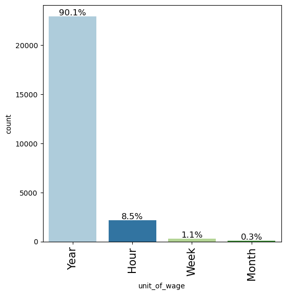

```python
labeled_barplot(df,"unit_of_wage",perc=True)
```

*Observation*

- Max unit of payments are Yearly and followed by Hourly

*full_time_position*

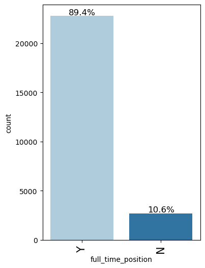

```python
labeled_barplot(df,"full_time_position",perc=True)
```

*Observation*

- Most of the people are fulltime position

*case_status*

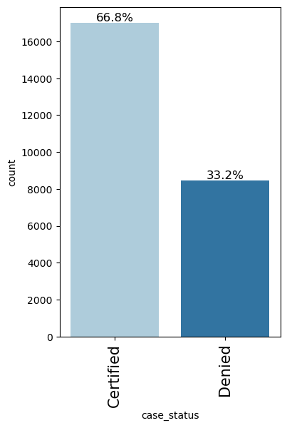

```python
labeled_barplot(df,"case_status",perc=True)
```

*Observation*

- The Certified are highest compared to Denied

### Fulltime position vs case_status

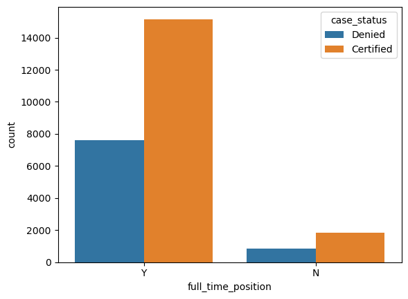

```python
sns.countplot(df,x="full_time_position",hue="case_status");
```

*Observation*

- No of people with fulltime position got visa is higher compared to without fulltime position

### Education vs visa status

- Those with higher education may want to travel abroad for a well-paid job. Does education play a role in Visa certification?

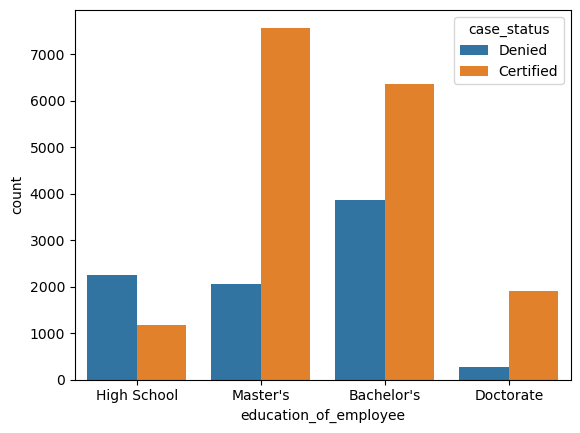

```python
sns.countplot(df,x="education_of_employee",hue="case_status");
```

*Observation*

- There is very good relation with the eduction and visa certified
- Doctorate the visa rejection is very less same as masters and followed by bacherl's, But the high school educted people had very good rate of rejection

### Visastatus vs continents

1. How does the visa status vary across different continents?

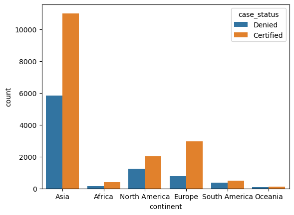

```python
sns.countplot(df,x="continent",hue="case_status");
```

*Observation*

### has_job_experience vs case_status

- Experienced professionals might look abroad for opportunities to improve their lifestyles and career development. Does work experience influence visa status?

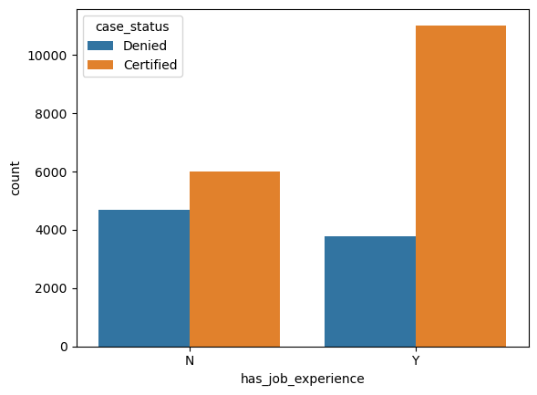

```python
sns.countplot(df,x="has_job_experience",hue="case_status");
```

*Observation*

- People with job expreience has higher changes of getting visa than the people with the no job expereience
- People with with out any job expreience has 50-50 change of visa approval

### has_job_experience vs education_of_employee

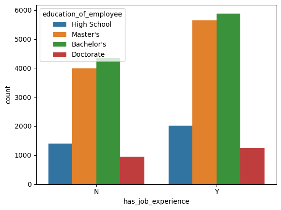

```python
sns.countplot(df,x="has_job_experience",hue="education_of_employee");
```

### unit_of_wage vs case_status

- In the United States, employees are paid at different intervals. Which pay unit is most likely to be certified for a visa?

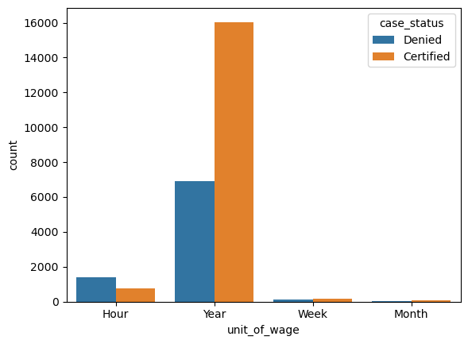

```python
sns.countplot(df,x="unit_of_wage",hue="case_status");
```

*Observation*

- The yearly package has the higher chance of getting the visa
- Hourly is having very less change of getting visa

### prevailing_wage VS case_status

- The US government has established a prevailing wage to protect local talent and foreign workers. How does the visa status change with the prevailing wage?

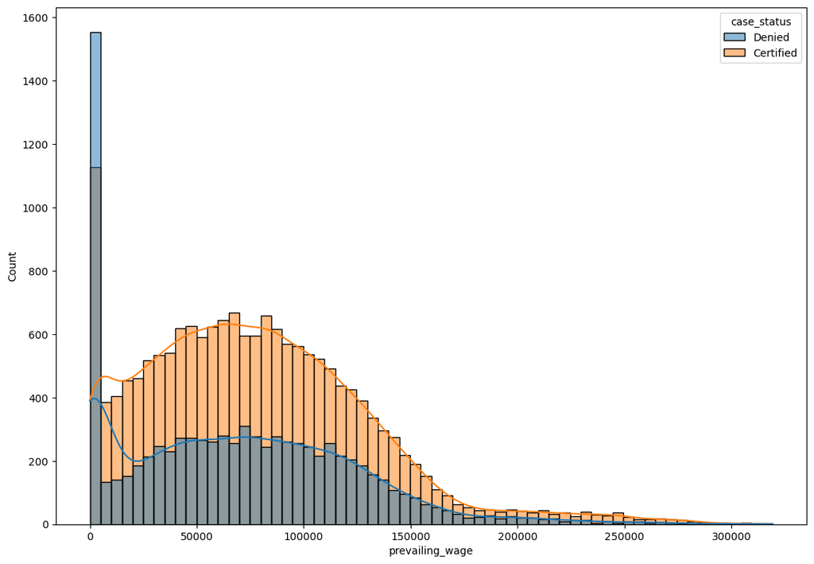

```python
plt.figure(figsize=(13,9))
sns.histplot(df,x="prevailing_wage",hue="case_status",kde=True)
plt.show()
```

*Observation*

## Data Preprocessing

- Missing value treatment (if needed)
- Feature engineering
- Outlier detection and treatment (if needed)
- Preparing data for modeling
- Any other preprocessing steps (if needed)

*Missing value treatment (if needed)*

```python
df.isnull().sum()
```

```
case_id                  0
continent                0
education_of_employee    0
has_job_experience       0
requires_job_training    0
no_of_employees          0
yr_of_estab              0
region_of_employment     0
prevailing_wage          0
unit_of_wage             0
full_time_position       0
case_status              0
dtype: int64
```

*Feature engineering*

- case_id is not use we can drop the value

```python
df=df.drop(["case_id"],axis=1)
```

*Outliers Checking*

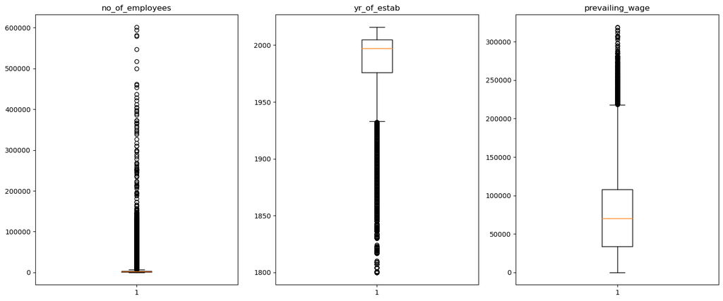

```python
numerical_col = data.select_dtypes(include=np.number).columns.tolist()
plt.figure(figsize=(20, 30))

for i, variable in enumerate(numerical_col):
    plt.subplot(5, 4, i + 1)
    plt.boxplot(data[variable], whis=1.5)
    plt.tight_layout()
    plt.title(variable)

plt.show()
```

```python
# to find the 25th percentile and 75th percentile for the numerical columns.
Q1 = data[numerical_col].quantile(0.25)
Q3 = data[numerical_col].quantile(0.75)

IQR = Q3 - Q1                   #Inter Quantile Range (75th percentile - 25th percentile)

lower_whisker = Q1 - 1.5*IQR    #Finding lower and upper bounds for all values. All values outside these bounds are outliers
upper_whisker = Q3 + 1.5*IQR
```

```python
((data[numerical_col] < lower_whisker) | (data[numerical_col] > upper_whisker)).sum()/data.shape[0]*100
```

```
no_of_employees     6.106750
yr_of_estab        12.794349
prevailing_wage     1.675824
dtype: float64
```

```python
def treat_outliers(df, col):
    """
    treats outliers in a variable
    col: str, name of the numerical variable
    df: dataframe
    col: name of the column
    """
    Q1 = df[col].quantile(0.25)  # 25th quantile
    Q3 = df[col].quantile(0.75)  # 75th quantile
    IQR = Q3 - Q1                # Inter Quantile Range (75th perentile - 25th percentile)
    lower_whisker = Q1 - 1.5 * IQR
    upper_whisker = Q3 + 1.5 * IQR

    # all the values smaller than lower_whisker will be assigned the value of lower_whisker
    # all the values greater than upper_whisker will be assigned the value of upper_whisker
    # the assignment will be done by using the clip function of NumPy
    df[col] = np.clip(df[col], lower_whisker, upper_whisker)

    return df
```

```python
df=treat_outliers(df,"no_of_employees")
df=treat_outliers(df,"yr_of_estab")
df=treat_outliers(df,"prevailing_wage")
```

## EDA

- It is a good idea to explore the data once again after manipulating it.

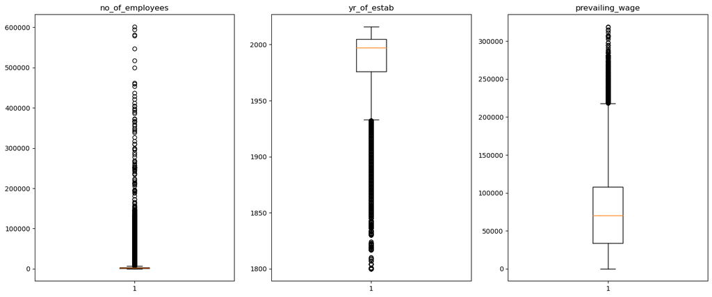

```python
numerical_col = data.select_dtypes(include=np.number).columns.tolist()
plt.figure(figsize=(20, 30))

for i, variable in enumerate(numerical_col):
    plt.subplot(5, 4, i + 1)
    plt.boxplot(data[variable], whis=1.5)
    plt.tight_layout()
    plt.title(variable)

plt.show()
```

```python
cat=df.select_dtypes(include=np.object_).columns.to_list()
for i in  (cat):
    print(df[i].value_counts())
    print("***"*25)
```

[output not shown]

## Preparing data for modeling

### Converting the all the categorical to numerical values

```python
replace_value ={
    "continent":{"Oceania":1,"Africa":2,"South America":3,"North America":4,"Europe":5,"Asia":6},
    "education_of_employee":{"Bachelor's":2,"Master's":3,"High School":1,"Doctorate":4},
    "has_job_experience":{"Y":2,"N":1},
    "requires_job_training":{"Y":1,"N":2},
    "full_time_position":{"Y":2,"N":1},
    "case_status":{"Certified":1,"Denied":0}
}
```

```python
df=df.replace(replace_value)
```

```python
X=df.drop("case_status",axis=1)
Y=df["case_status"]
```

```python
X=pd.get_dummies(X,columns=["unit_of_wage","region_of_employment"],dtype=float)
```

### Train Test split the data

```python
x_train,x_test,y_train,y_test=train_test_split(X,Y,test_size=0.30,random_state=1,stratify=Y)
```

### Shape of test and train

```python
x_train.shape,x_test.shape
```

```
((17836, 17), (7644, 17))
```

*Observation*

- The 17836 observation in train and 7644 in the test

### Model Performance Evaluation¶

*Which case is more important?*

- We need to reduce both False Negatives and False Positives

### Define a Function for Calssification score and the confution matrix for train and test result

```python
def check_model_performance(model,predictor,target):
    #we need the accuracy, recall , precision score
    y_predict=model.predict(predictor)
    recall=metrics.recall_score(target,y_predict)
    accuracy=metrics.accuracy_score(target,y_predict)
    precision=metrics.precision_score(target,y_predict)
    f1= metrics.f1_score(target,y_predict)
    score_value=pd.DataFrame({
        "recall":recall,
        "accuracy":accuracy,
        "precision":precision,
        "f1_score":f1,
    },index=[0])
    return score_value
```

```python
def checking_confution_matrix(model,predictor,target):
    #confution metrix takes 2 parameters
    y_predict = model.predict(predictor)
    cm=confusion_matrix(target,y_predict)
    label= np.asarray([
        ["{0:0.0f}".format(item) + "\n{0:0.2%}".format(item/cm.flatten().sum())]
        for item in cm.flatten()
    ]).reshape(2,2)
    sns.heatmap(cm,annot=label,fmt="")
    plt.ylabel("Actual_values")
    plt.xlabel("Predicted_values")
    plt.title("Confusion Matrix")
```